# An Analysis of Reported Heights and Weights of Current NFL Players

December 2018

## Summary

- Project examines heights and weights of current NFL players for inaccuracies arising from self-reported nature of figures
- Neither player heights, nor player weights follow Benford distribution, but they should both be approximately normal if their disributions are similar to those of the overall population of adult males
- Population further segmented into groups by player position and examined for normality
- For offensive linemen weight distribution, I reproduced the Benford getSuspects function by running Chi-squared tests on different quantiles to see which ones deviated the most from the expected normal densities
- After significant analytical investigation, I visualize and explore other relationships in the dataset

## Data Scraped from Sports Analytics Website Lineups.com

[figure not shown]

## Player Heights Don't Follow Benford Distribution and Range from 66 to 81 Inches

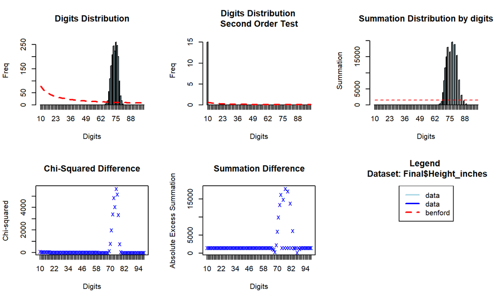

## Player Weights Don't Follow Benford Either and Range from 149 to 362 lbs

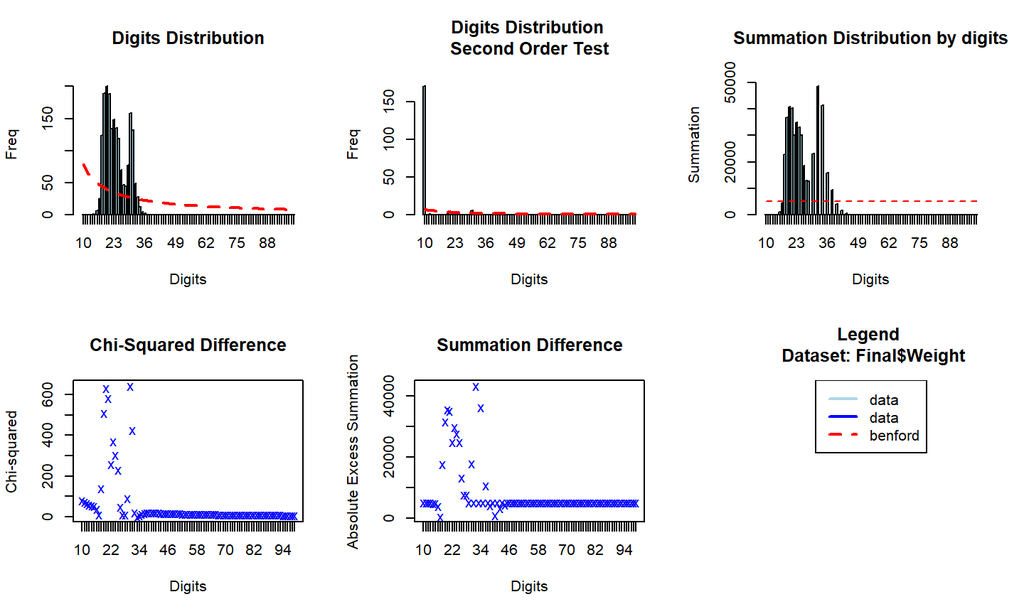

## Weights Appear Multi-Modal While Heights Have Bell Shape

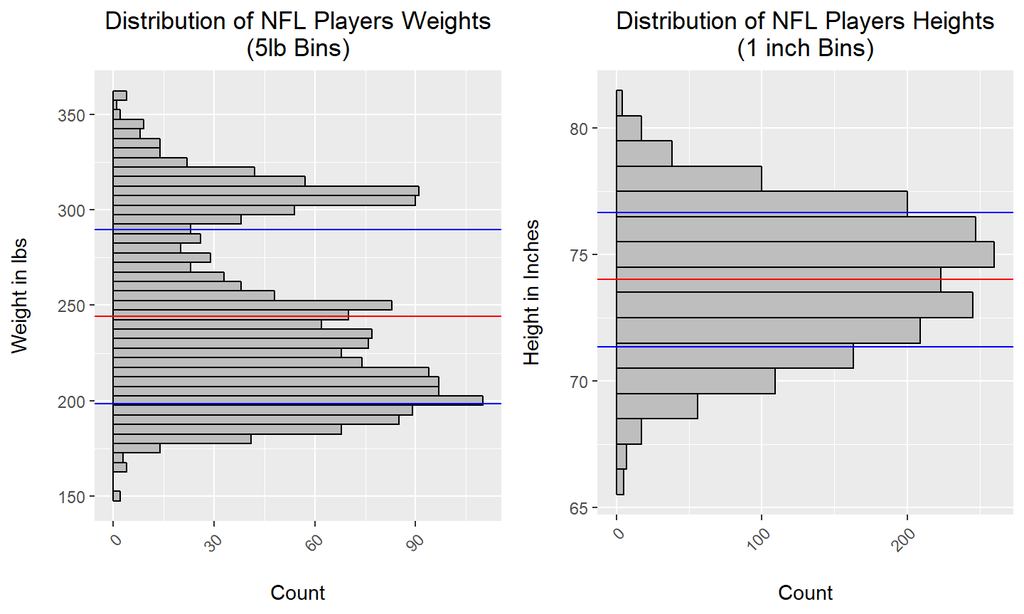

## Q-Q Plots Indicate Neither Are Drawn from Normally Distributed Population

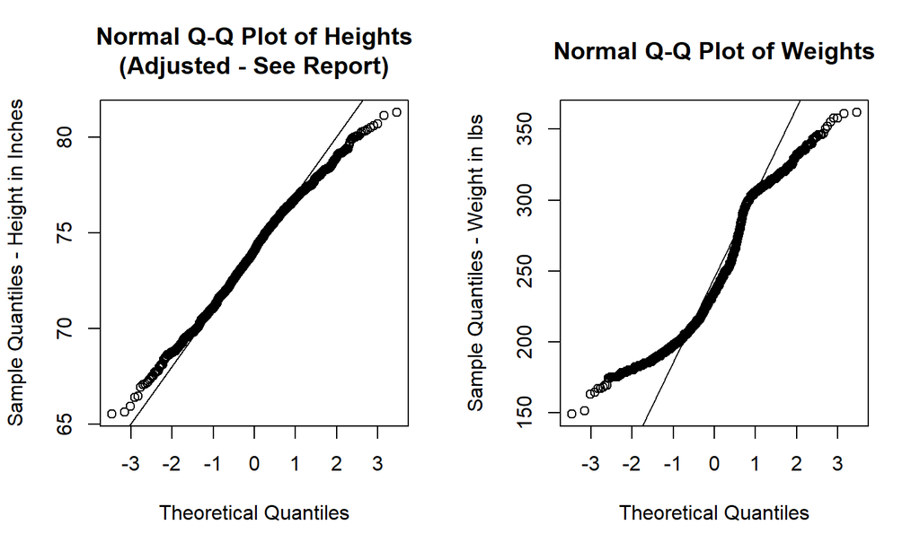

## Player Heights Were Adjusted With Randomly Drawn Decimal Endings To Address Discreteness

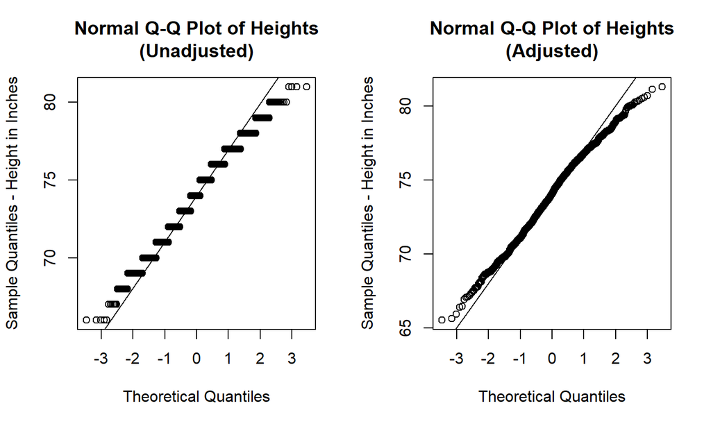

## Shapiro-Wilk Test of Normality Agrees They're Not Normally Distributed

- Shapiro-Wilk tests null hypothesis that a sample came from a normally distributed population. p-value is less than 0.05 so we can reject the null hypothesis at 95% LOC that height and weight were drawn from normally distributed population (See report for details)

```
##
##  Shapiro-Wilk normality test
##
## data:  Final$Weight
## W = 0.93497, p-value < 2.2e-16
```

```
##
##  Shapiro-Wilk normality test
##
## data:  Final$Height_inches
## W = 0.9818, p-value = 7.898e-15
```

## Conclusions from Basic Visualizations of Height and Weights

- Player weights were not normally distributed and heights appear off as well
- Height distribution has elements of discreteness caused by rounding to the nearest inch in reported height values
- There were only 16 different values for height: 66 inches to 81 inches inclusive
- I addressed height discreteness by adding decimal endings from uniform distribution centered at zero and plus / minus half an inch to mimic rounding in real life
- Next, I'll analyze the distribution of heights and weights by position

## Quarterback Height and Weight Distributions Look Bell Shaped

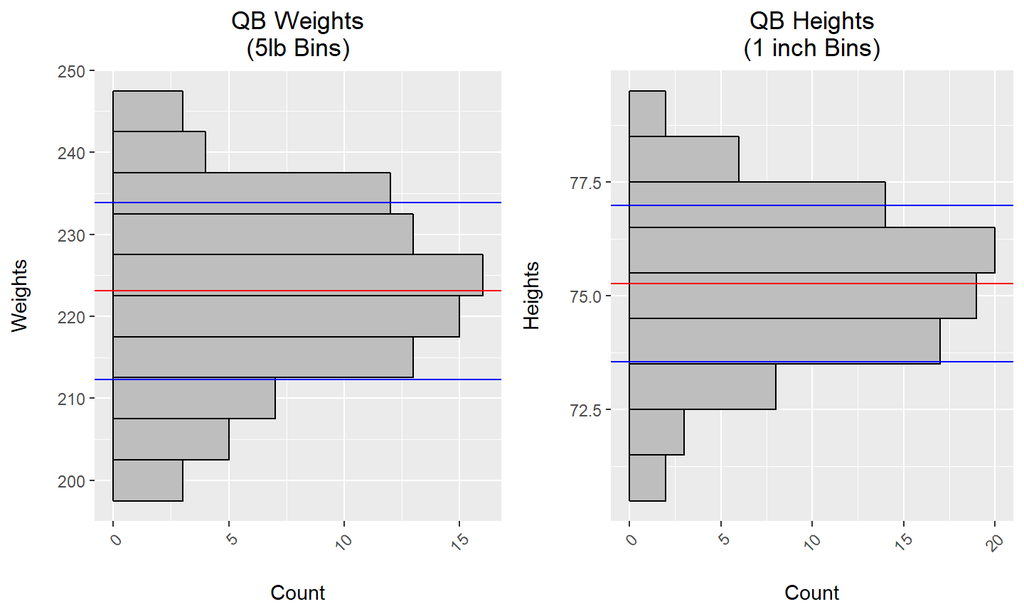

## QQ Plots for Quarterback Suggest Normal Distribution

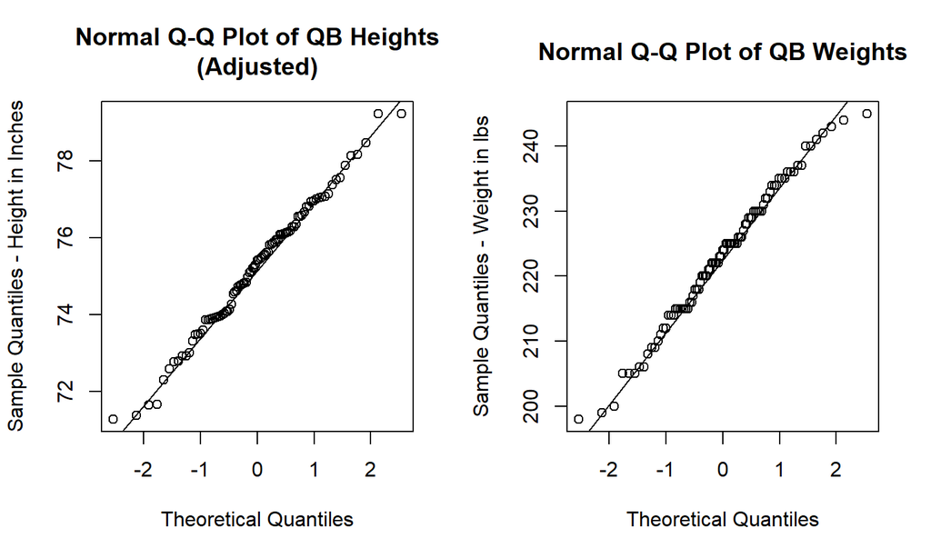

## Shapiro-Wilk Tests Agrees That Quarterback Distributions May Be Normal

- Both have p-values far greater than 0.05. Notably, if the heights are not adjusted, the p-value becomes small enough to reject the null hypothesis.

```
##
##  Shapiro-Wilk normality test
##
## data:  QB_Final$Weight
## W = 0.98809, p-value = 0.5831
```

```
##
##  Shapiro-Wilk normality test
##
## data:  QB_Final$Height_inches_uniform
## W = 0.99083, p-value = 0.7844
```

## In Full Report and Shiny App, We Also Examine Distributions, QQ-Plots, and Tests of Normality for Other Positions

- Omitted from report for sake of compactness and brevity
- We'll look at offensive linemen next for which we apply further testing on to retrieve suspects

## Offensive Line: Distributions Look Bell Shaped But Skewed For Weight

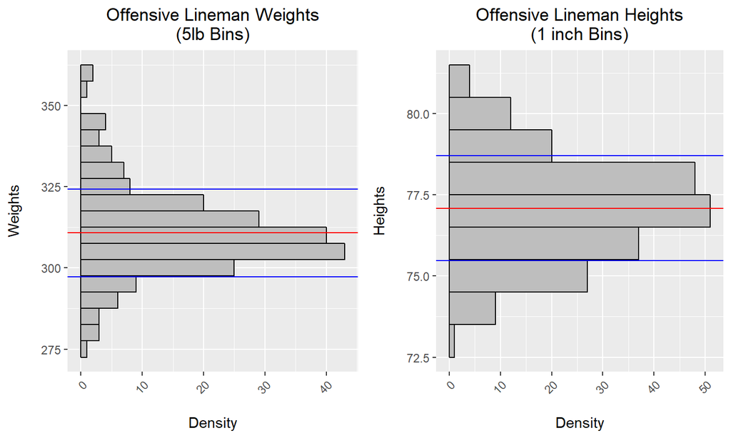

## Q-Q Plots Indicate Height Close to Normal But Weight is Not

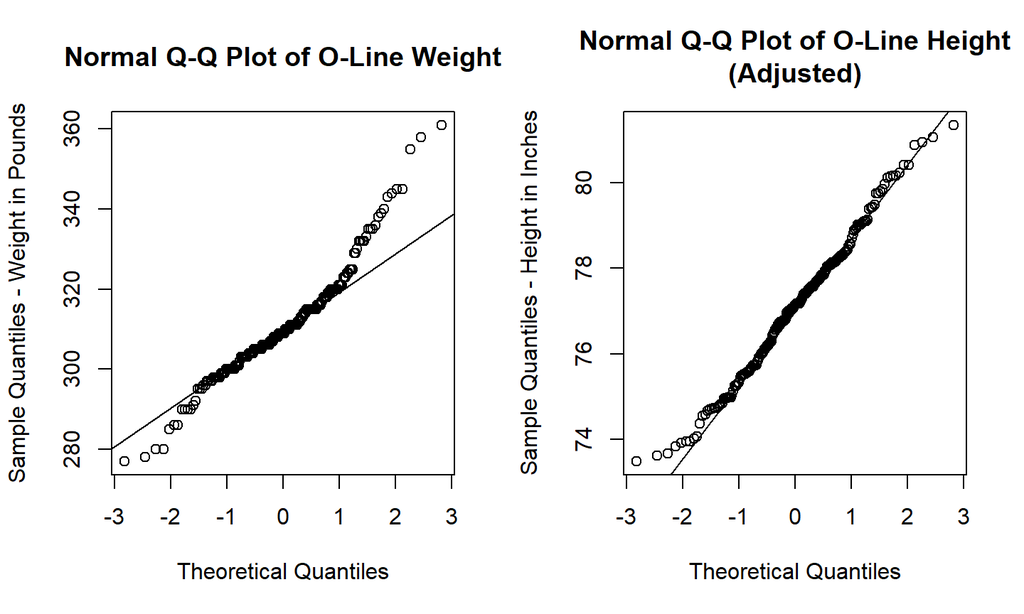

## Shapiro-Wilk Tests Agrees Offensive Line Height May be Normal But Not Weight

```
##
##  Shapiro-Wilk normality test
##
## data:  OL_Final$Weight
## W = 0.95225, p-value = 1.956e-06
```

```
##
##  Shapiro-Wilk normality test
##
## data:  OL_Final$Height_inches_uniform
## W = 0.99144, p-value = 0.257
```

## Using The Chi-Squared Test Statistic, We'll Find Weight Bins With The Largest Deviations

- In histogram, weights bucketed in five pound increments with 85 different values in that range so 17 buckets total
- Using each bucket, we can calculate expected area under the curve from pnorm function and multiply by total sample size to get how many samples expected in that quantile
- From there, we can calculate observed minus expected and generate chi-squared values for each bin
- We then select the bins with the largest chi squared test statistic values - this is how the benford analysis package selects suspects

## Biggest Suspects Are in the Heaviest Quantile - See Below

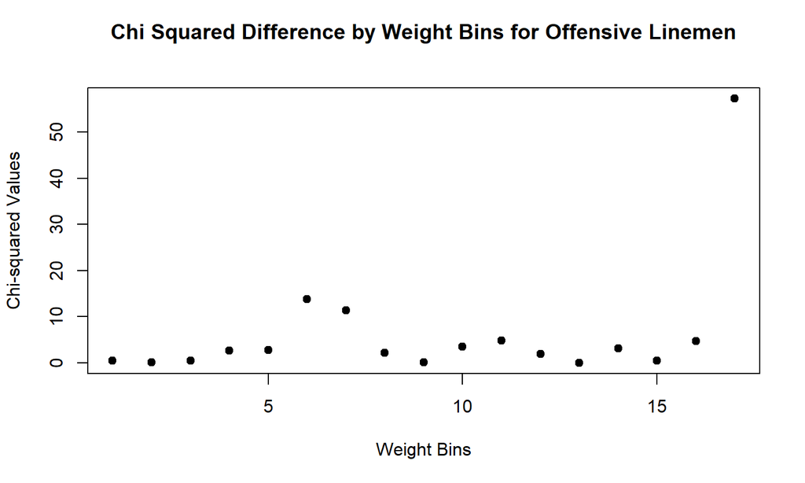

## These players are Marcus Cannon of the New England Patriots and Zach Banner of the Pittsburgh Steelers

[figure not shown]

## Both players Struggled With Weight in the Past and Have Weight-Related Incentives in Contracts

- Both players are listed at varying weights depending on the website and time period and have struggled with being too heavy in the past
- Both also have performance incentives in their contract for making a certain weight during training camp
- Our method of getting suspects via the largest Chi-Squared values appears somewhat successful in finding unusual observations in this test case

## Some Other Selected Relationships Visualized (More in Report/Shiny) - 1

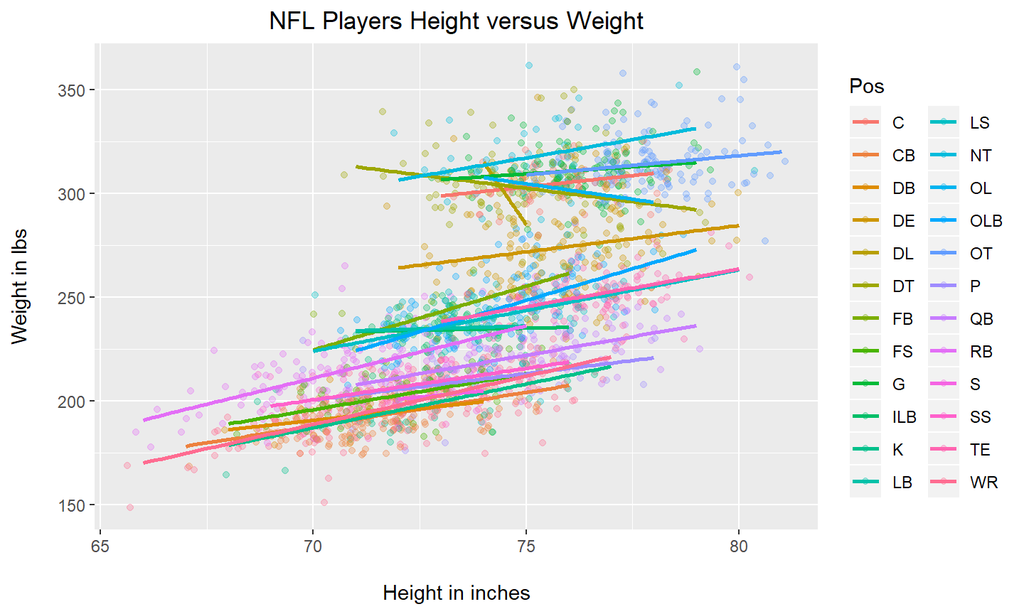

## Some Other Selected Relationships Visualized (More in Report/Shiny) - 2

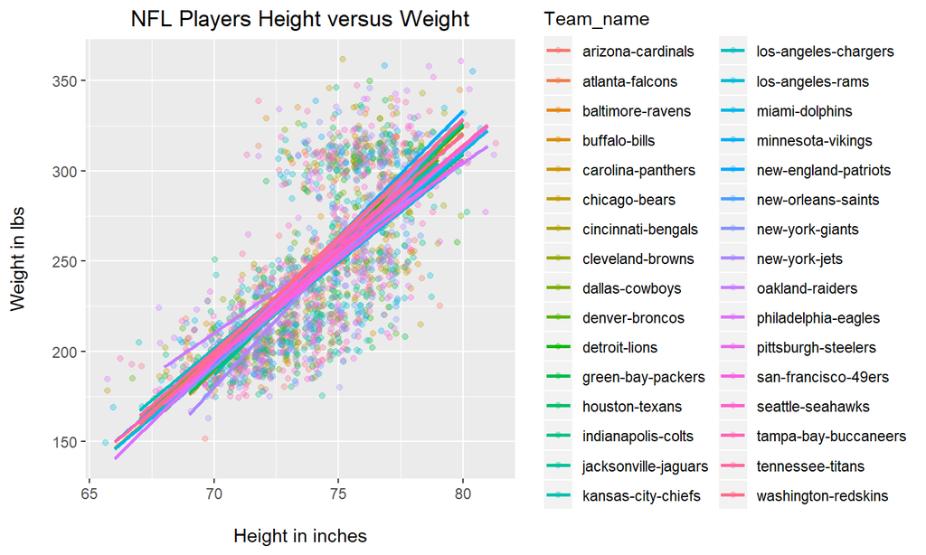

## Some Other Selected Relationships Visualized (More in Report/Shiny) - 3

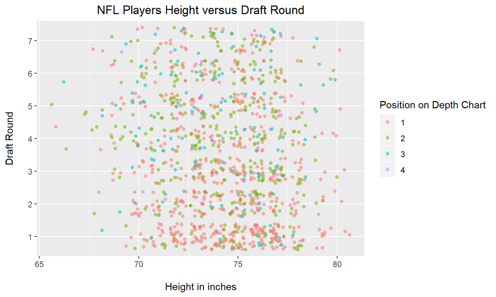

## Some Other Selected Relationships Visualized (More in Report/Shiny) - 4

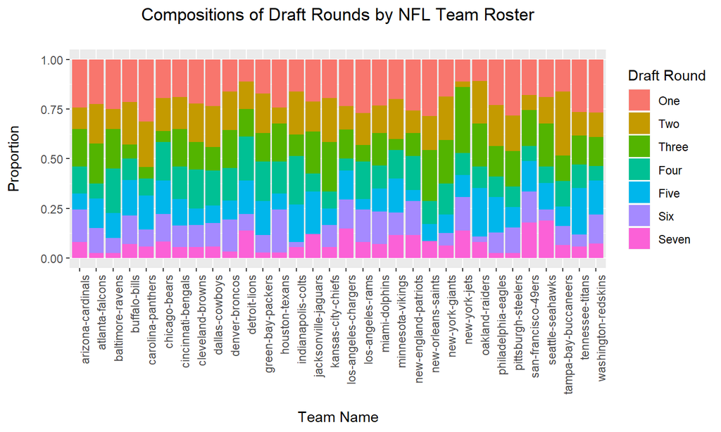